# Week 10: Hypothesis Testing and Confidence Intervals

Descriptive & Inferential Statistics for Business Analytics

Author

Affiliation

Dr. Smith

University of South Florida

**Session Overview:**

In this lecture you will learn:

- How to summarize data using descriptive statistics and visualize distributions.
- The core concepts of hypothesis testing, including null and alternative hypotheses, p‑values, and significance levels.
- The use of t‑tests and correlation analysis.

## Descriptive Statistics and Data Distributions

Before delving into inferential methods, it is important to summarize and visualize your data.

### Descriptive Statistics with pandas

Descriptive statistics provide a quick overview of the central tendencies and variability in your data. The following example demonstrates how to compute measures such as mean, median, mode, variance, and standard deviation using pandas.

```python
import pandas as pd

# Sample sales data
data = {'sales': [150, 200, 250, 200, 210, 205, 175, 225, 275, 223, 209, 195, 192, 240, 237]}
df = pd.DataFrame(data)

# Calculating descriptive statistics
print("Mean:", df['sales'].mean())
print("Median:", df['sales'].median())
print("Mode:", df['sales'].mode()[0])
print("Variance:", df['sales'].var())
print("Standard Deviation:", df['sales'].std())
```

```
Mean: 212.4
Median: 209.0
Mode: 200
Variance: 954.4
Standard Deviation: 30.893364983439405
```

**Note:**

These basic statistics are essential for understanding the overall distribution of your data before performing further analysis.

### Visualizing Data Distributions

Visualization enhances your understanding of how data points are spread. Histograms and box plots are useful to quickly grasp data distributions and identify outliers.

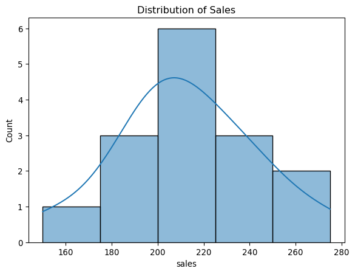

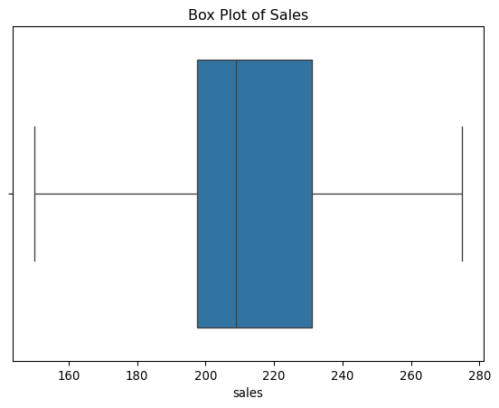

```python
import seaborn as sns
import matplotlib.pyplot as plt

# Histogram with KDE (Kernel Density Estimate)
sns.histplot(df['sales'], bins=5, kde=True)
plt.title('Distribution of Sales')
plt.show()

# Box plot for sales data
sns.boxplot(x=df['sales'])
plt.title('Box Plot of Sales')
plt.show()
```

**Quick Tip:**

Always inspect your data visually to spot potential issues like skewness or outliers.

## Inferential Statistics: Hypothesis Testing and Confidence Intervals

Inferential statistics enable you to draw conclusions about a population based on sample data. In business, this is crucial when comparing different strategies or estimating key performance indicators.

### Review of the Normal Distribution

Many inferential tests are based on the normal distribution. Here’s a quick refresher on its key aspects:

- **Mean (µ):** Center of the distribution.
- **Standard Deviation (σ):** Indicates spread.
- **Z-Scores:** Standardized measure that tells how many standard deviations a data point is from the mean.
- **Critical Cutoff Points:** For a 95% confidence level (two-tailed), the critical z-values are approximately -1.96 and +1.96.

[figure not shown]

Normal Distribution

[figure not shown]

P-Value

## Hypothesis Testing

This document provides a detailed explanation of the differences between a one-sample t-test, a two-sample t-test, and a paired t-test. It is structured to help students understand the purpose, assumptions, and applications of each test.

## One-Sample t-Test

A **one-sample t-test** is used when you want to compare the mean of a single sample to a known or hypothesized value.

### Purpose

It assesses whether the sample mean significantly differs from a predetermined value (often a known population mean).  
*Example:* Imagine you have a sample of 30 students’ test scores and you want to determine if their average score is different from a national average of 75.

### Assumptions

- The data are approximately normally distributed (particularly important with smaller sample sizes).
- The sample is randomly drawn from the population.

### Test Statistic

The t-statistic is computed by subtracting the hypothesized population mean from the sample mean and then dividing by the standard error of the sample mean:

$$t = \frac{\bar{x} - \mu_0}{s/\sqrt{n}}$$

where:

- $\bar{x}$ is the sample mean,
- $\mu_0$ is the hypothesized mean,
- $s$ is the sample standard deviation,
- $n$ is the sample size.

## Two-Sample t-Test

A **two-sample t-test** is employed when comparing the means of two independent groups to see if there is a statistically significant difference between them.

### Purpose

It determines if two independent samples come from populations with different means.

*Example:* Consider a study comparing the effectiveness of two different teaching methods by examining test scores from two separate groups of students, one using Method A and the other using Method B.

### Types

- **Equal Variance (Pooled) t-test:** Assumes both groups have the same population variance.
- **Unequal Variance (Welch’s) t-test:** Does not assume equal variances between the two groups.

### Assumptions

- The two samples are independent of each other.
- Each sample should be drawn from a normally distributed population.
- Homogeneity of variances (for the pooled version) or appropriate accommodation for heterogeneity (using Welch’s version).

### Test Statistic

The t-statistic is calculated by taking the difference between the two sample means and dividing it by the standard error of the difference between the means. For equal variances, this standard error is based on a pooled estimate of variance.

## Paired t-Test

A **paired t-test** (or dependent t-test) is applied when you have two related measurements—usually from the same subjects—and you want to determine if there is a significant difference between these paired observations.

### Purpose

It evaluates the mean difference between paired or matched observations.  
*Example:* A pre-test/post-test study where the same students take a test before and after an educational intervention. Each student serves as their own control.

### Assumptions

- The differences between paired observations should be approximately normally distributed.
- The pairs are meaningfully matched or are repeated measures from the same subjects.

### Test Statistic

The paired t-test converts the problem into a one-sample t-test by calculating the difference for each pair and then testing if the average of these differences is significantly different from zero:

$$t = \frac{\bar{d}}{s_d/\sqrt{n}}$$

where:

- $\bar{d}$ is the mean difference between pairs,
- $s_d$ is the standard deviation of the differences,
- $n$ is the number of pairs.

### Summary of Key Differences

- **Data Structure:**
  - **One-Sample t-Test:** Involves one sample compared to a known value.
  - **Two-Sample t-Test:** Involves two independent samples compared against each other.
  - **Paired t-Test:** Involves pairs of related observations (or the same subjects measured twice).
- **Study Design:**
  - **One-Sample:** Tests a single group against a standard.
  - **Two-Sample:** Compares two separate groups.
  - **Paired:** Compares two conditions or time points within the same subjects, controlling for inter-subject variability.
- **Error Structure and Variability:**
  - **One-Sample:** Variability is only within the single sample.
  - **Two-Sample:** Variability arises from both samples, and independence is crucial.
  - **Paired:** Variability is reduced because each subject serves as their own control, focusing on the differences within pairs.

We will only cover three t-tests (all with two-tailed tests) in this lecture: one-sample, two-sample, and paired t-tests. The code snippets provided are for illustrative purposes only and should be adapted to your specific data and research questions.

T‑tests allow you to compare means and draw inferences about business performance. In the following examples, we explore three types of t‑tests—one-sample, two-sample, and paired—each illustrated with three concrete business scenarios.

#### One-Sample T‑Test

A one-sample t‑test compares the mean of a single sample to a known benchmark or target value. This is useful when you want to determine if your process or performance meets an expected standard.

You can read more about the method being used in the sample code in this section by reviewing the documentation found [here](https://docs.scipy.org/doc/scipy/reference/generated/scipy.stats.ttest_1samp.html)

**Business Example 1: Customer Satisfaction Rating**

*Question: Is the average customer satisfaction rating significantly different from our target rating of 4.0?*

```python
import numpy as np
from scipy import stats

# Sample customer satisfaction ratings (scale of 1 to 5)
ratings = np.array([4.2, 3.8, 4.0, 4.5, 3.9, 4.1, 4.3])
benchmark = 4.0

# Perform a one-sample t-test
t_stat, p_value = stats.ttest_1samp(ratings, benchmark)
print("One-Sample T-Test: Customer Satisfaction")
print("T-Statistic:", t_stat)
print("P-value:", p_value)
```

```
One-Sample T-Test: Customer Satisfaction
T-Statistic: 1.2545000963743653
P-value: 0.2563154589158218
```

*Interpretation:*

A p-value below 0.05 suggests that the average customer satisfaction is significantly different from the target of 4.0, prompting a review of service quality.

**Business Example 2: Production Cost Benchmark**

*Question: Does the average production cost per unit significantly differ from the industry standard of $50?*

```python
# Sample production costs per unit (in dollars)
production_costs = np.array([48, 52, 47, 53, 50, 49, 51])
industry_standard = 50

# Perform a one-sample t-test
t_stat, p_value = stats.ttest_1samp(production_costs, industry_standard)
print("\nOne-Sample T-Test: Production Cost")
print("T-Statistic:", t_stat)
print("P-value:", p_value)
```

```
One-Sample T-Test: Production Cost
T-Statistic: 0.0
P-value: 1.0
```

*Interpretation:*

If the p-value is below 0.05, it indicates that your production costs differ significantly from the $50 benchmark, signaling the need to investigate cost drivers.

**Business Example 3: Average Delivery Time**

*Question: Is the average delivery time significantly different from our promised delivery time of 3 days?*

```python
# Sample delivery times (in days)
delivery_times = np.array([2.8, 3.1, 3.0, 2.9, 3.2, 2.7, 3.0])
promised_time = 3.0

# Perform a one-sample t-test
t_stat, p_value = stats.ttest_1samp(delivery_times, promised_time)
print("\nOne-Sample T-Test: Delivery Time")
print("T-Statistic:", t_stat)
print("P-value:", p_value)
```

```
One-Sample T-Test: Delivery Time
T-Statistic: -0.6599120175960941
P-value: 0.5338076803004532
```

*Interpretation:*

A significant p-value would indicate that the actual delivery times differ from the promised 3-day standard, which may prompt operational reviews.

#### Two-Sample T‑Test

A two-sample t‑test compares the means of two independent groups. This test is ideal for evaluating the effectiveness of different business strategies.

You can read more about the method being used in the sample code in this section by reviewing the documentation found [here](https://docs.scipy.org/doc/scipy/reference/generated/scipy.stats.ttest_ind.html)

**Business Example 1: Marketing Campaign Performance**

*Question: Does Campaign A generate higher sales than Campaign B?*

```python
# Sample sales data for two marketing campaigns
campaign_A = np.array([100, 102, 98, 105, 110, 95, 103])
campaign_B = np.array([95, 97, 96, 92, 90, 98, 94])

# Perform a two-sample t-test
t_stat, p_value = stats.ttest_ind(campaign_A, campaign_B)
print("\nTwo-Sample T-Test: Marketing Campaign Performance")
print("T-Statistic:", t_stat)
print("P-value:", p_value)
```

```
Two-Sample T-Test: Marketing Campaign Performance
T-Statistic: 3.420329030175706
P-value: 0.005075487486088886
```

*Interpretation:*

A p-value below 0.05 suggests a statistically significant difference in sales between the two campaigns, guiding marketing strategy adjustments.

**Business Example 2: Branch Revenue Comparison**

*Question: Do two different branches of your retail chain show a significant difference in average monthly revenue?*

```python
# Sample monthly revenue data (in thousands) for two branches
branch_X = np.array([150, 155, 148, 160, 158, 152, 157])
branch_Y = np.array([145, 148, 150, 142, 147, 149, 151])

# Perform a two-sample t-test
t_stat, p_value = stats.ttest_ind(branch_X, branch_Y)
print("\nTwo-Sample T-Test: Branch Revenue Comparison")
print("T-Statistic:", t_stat)
print("P-value:", p_value)
```

```
Two-Sample T-Test: Branch Revenue Comparison
T-Statistic: 3.3579299146322867
P-value: 0.005695961373319701
```

*Interpretation:*

A significant p-value indicates that one branch might be outperforming the other, which can inform resource allocation or management decisions.

**Business Example 3: Employee Productivity Comparison**

*Question: Do the Sales and Customer Support departments differ significantly in average daily productivity (e.g., number of resolved cases or sales calls)?*

```python
# Sample productivity data (e.g., resolved cases per day)
sales_department = np.array([30, 32, 28, 35, 33, 31, 29])
support_department = np.array([25, 27, 26, 24, 28, 26, 27])

# Perform a two-sample t-test
t_stat, p_value = stats.ttest_ind(sales_department, support_department)
print("\nTwo-Sample T-Test: Department Productivity")
print("T-Statistic:", t_stat)
print("P-value:", p_value)
```

```
Two-Sample T-Test: Department Productivity
T-Statistic: 4.7925723781702025
P-value: 0.0004390528365190285
```

*Interpretation:*

A p-value below 0.05 suggests that there is a significant difference in productivity between the departments, which may lead to tailored training or resource adjustments.

#### Paired T‑Test

A paired t‑test is used for comparing two related samples—for example, measurements taken before and after a specific intervention.

You can read more about the method being used in the sample code in this section by reviewing the documentation found [here](https://docs.scipy.org/doc/scipy/reference/generated/scipy.stats.ttest_rel.html)

**Business Example 1: Impact of a New Pricing Strategy**

*Question: Does the implementation of a new pricing strategy lead to an increase in sales?*

```python
# Sales data before and after a new pricing strategy (paired observations)
sales_before = np.array([100, 102, 98, 105, 110, 95, 103])
sales_after  = np.array([105, 107, 100, 108, 115, 98, 105])

# Perform a paired t-test
t_stat, p_value = stats.ttest_rel(sales_before, sales_after)
print("\nPaired T-Test: Pricing Strategy Impact")
print("T-Statistic:", t_stat)
print("P-value:", p_value)
```

```
Paired T-Test: Pricing Strategy Impact
T-Statistic: -6.762522260005742
P-value: 0.0005103778947558961
```

*Interpretation:*

A p-value below 0.05 provides evidence that the new pricing strategy has a significant impact on sales performance.

**Business Example 2: Customer Support Training Effectiveness**

*Question: Has a customer support training program reduced the average response time?*

```python
# Average response times (in minutes) before and after a training program (paired observations)
response_before = np.array([10, 12, 11, 9, 13, 10, 11])
response_after  = np.array([8, 9, 7, 8, 10, 8, 9])

# Perform a paired t-test
t_stat, p_value = stats.ttest_rel(response_before, response_after)
print("\nPaired T-Test: Customer Support Response Time")
print("T-Statistic:", t_stat)
print("P-value:", p_value)
```

```
Paired T-Test: Customer Support Response Time
T-Statistic: 6.584071688552608
P-value: 0.0005892669340900919
```

*Interpretation:*

A significant p-value suggests that the training program has effectively reduced response times, leading to improved customer service.

**Business Example 3: Website Redesign Impact**

*Question: Has a website redesign led to a change in the average session duration for users?*

```python
# Average session durations (in minutes) before and after a website redesign (paired observations)
session_before = np.array([5.5, 6.0, 5.8, 6.2, 5.9, 6.1, 5.7])
session_after  = np.array([6.0, 6.5, 6.3, 6.7, 6.4, 6.6, 6.2])

# Perform a paired t-test
t_stat, p_value = stats.ttest_rel(session_before, session_after)
print("\nPaired T-Test: Website Redesign Impact")
print("T-Statistic:", t_stat)
print("P-value:", p_value)
```

```
Paired T-Test: Website Redesign Impact
T-Statistic: -inf
P-value: 0.0
```

*Interpretation:*

If the p-value is below 0.05, it suggests that the website redesign has significantly changed the user session duration, indicating potential improvements in user engagement.

Each of these examples demonstrates how t‑tests can be applied to answer practical business questions—from comparing performance against benchmarks to evaluating the impact of strategic changes. These statistical tools enable you to make data-driven decisions with confidence.

While today’s focus is on hypothesis testing, it is also valuable to understand how correlation and regression analysis can complement inferential statistics in business analytics.

### Correlation Analysis with pandas

Correlation analysis quantifies the degree of association between variables. The following example computes the Pearson correlation between sales, marketing spend, and customer satisfaction.

```
                          sales  marketing_spend  customer_satisfaction
sales                  1.000000        -0.136422              -0.030357
marketing_spend       -0.136422         1.000000               0.108685
customer_satisfaction -0.030357         0.108685               1.000000
```

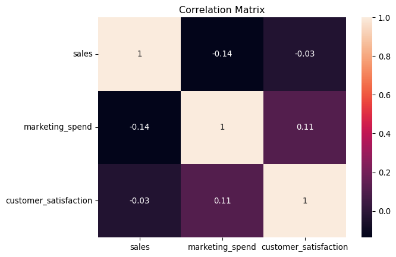

```python
import numpy as np

# Create sample data for correlation analysis
np.random.seed(42)
data = {
  'sales': np.random.normal(200, 50, 100),
  'marketing_spend': np.random.normal(50, 10, 100),
  'customer_satisfaction': np.random.uniform(1, 5, 100)
}
df_corr = pd.DataFrame(data)

# Compute the correlation matrix
correlation_matrix = df_corr.corr()
print(correlation_matrix)

# Visualize correlation with seaborn heatmap
sns.heatmap(correlation_matrix, annot=True)
plt.title("Correlation Matrix")
plt.show()
```

## Reflective Questions

1. **Descriptive Statistics:** What does it imply if the standard deviation of a dataset is high?
2. **Hypothesis Testing:** How can the results of a t‑test affect business decision-making?
3. **Correlation:** How do correlation coefficients guide your analysis of relationships between variables?

## Summary and Next Steps

**Final Thought:**

Mastering these statistical techniques is crucial for turning raw data into actionable insights. Practice these methods on real datasets and always maintain ethical standards in your analyses.

**Next Steps:** - Experiment with your own datasets by computing descriptive and inferential statistics. - Apply hypothesis testing and confidence interval estimation to A/B testing scenarios. - Explore further regression analysis and ethical data handling practices. - Bring any questions to our next session or visit office hours.

Happy coding and data exploring!

*Dr. Smith ©️2025*